# Lab 2 Report

## Part 1: Decrypting Substitution Cipher Using Frequency Analysis

Completed by: Koh Aik Hong, 1005139

```python
fin = open("story_cipher.txt", mode="r", encoding="utf-8", newline="\n")
text = fin.read()
text
```

```
'MXQJ YI IOCFXEWUQH. VEH Q BEEEEEDW, BEEEDW JYCU Y XQLU DULUH REJXUHUT UDWQWYDW COIUBV YD JXYI VHQDSXYIU. Y TYT DEJ KDTUHIJQDT MXQJ YJ YI. DEM JXQJ JXU IXEM YI XQLYDW YJI BQIJ IUQIED, Y TUSYTUT JE VYDQBBO WYLU YD, WYLU IOCFXEWUQH Q JHO VHEC JXU LUHO IJQHJ. Y MEDTUHUT XEM XQLU Y CYIIUT EKJ ED JXU QDY…
```

```python
import matplotlib.pyplot as plt
```

```python
letter_frequency = {}
for i in text:
    if i not in letter_frequency.keys():
        letter_frequency[i] = 1
    else:
        letter_frequency[i] += 1
letter_frequency
```

```
{'M': 50,
 'X': 160,
 'Q': 213,
 'J': 263,
 ' ': 626,
 'Y': 229,
 'I': 198,
 'O': 58,
 'C': 70,
 'F': 43,
 'E': 206,
 'W': 71,
 'U': 305,
 'H': 131,
 '.': 39,
 'V': 50,
 'B': 102,
 'D': 205,
 ',': 39,
 'L': 29,
 'R': 35,
 'T': 98,
 'S': 61,
 'K': 51,
 'A': 20,
 'N': 3,
 'Z': 3,
 'P': 1}
```

```python
new = sorted(letter_frequency, key=letter_frequency.get, reverse=True)
new
```

```
[' ',
 'U',
 'J',
 'Y',
 'Q',
 'E',
 'D',
 'I',
 'X',
 'H',
 'B',
 'T',
 'W',
 'C',
 'S',
 'O',
 'K',
 'M',
 'V',
 'F',
 '.',
 ',',
 'R',
 'L',
 'A',
 'N',
 'Z',
 'P']
```

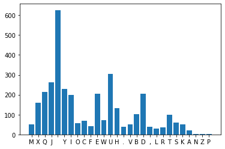

```python
frequency = letter_frequency.values()
letter = list(letter_frequency.keys())

plt.bar(range(len(letter_frequency)), frequency, tick_label=letter)
plt.show()
```

### Using etaoin shrdlu and matching the most frequent letters in story_cipher.txt to the most frequently used letters in english,

U = E

J = T

Y = A

Q = O

E = I

D = N

I = S

X = H

H = R

B = D

T = L

W = U

### However, it appears that YJ = IT and YI = IS, since they are often used together.

Thus, it is likely that Y = I rather than Y = A as obtained using ETAOIN SHRDLU. This also means that the value of E is currently unknown.

```python
def decrypt(text, cipher, substitute):
    output = ""
    for letter in text:
        if letter in cipher.upper():
            index = cipher.upper().index(letter)
            output += substitute[index].upper()
        else:
            output += letter
    return output
```

```python
decrypted_text_v1 = decrypt(text, "ujyqdixhbtw", "etionshrdlu")
decrypted_text_v1
```

```
'MHOT IS SOCFHEUEOR. VER O DEEEEENU, DEEENU TICE I HOLE NELER RETHEREL ENUOUINU COSEDV IN THIS VRONSHISE. I LIL NET KNLERSTONL MHOT IT IS. NEM THOT THE SHEM IS HOLINU ITS DOST SEOSEN, I LESILEL TE VINODDO UILE IN, UILE SOCFHEUEOR O TRO VREC THE LERO STORT. I MENLEREL HEM HOLE I CISSEL EKT EN THE ONI…
```

### Searching for mistakes

it appears that the substitute for Q = O is wrong since O is not a word, the most likely value for Q is A.

```python
decrypted_text_v2 = decrypt(text, "ujyqdixhbtw", "etianshrdlu")
decrypted_text_v2
```

```
'MHAT IS SOCFHEUEAR. VER A DEEEEENU, DEEENU TICE I HALE NELER RETHEREL ENUAUINU COSEDV IN THIS VRANSHISE. I LIL NET KNLERSTANL MHAT IT IS. NEM THAT THE SHEM IS HALINU ITS DAST SEASEN, I LESILEL TE VINADDO UILE IN, UILE SOCFHEUEAR A TRO VREC THE LERO START. I MENLEREL HEM HALE I CISSEL EKT EN THE ANI…
```

### Analysis

It appears that M = W, assuming that MHAT = WHAT

```python
decrypted_text_v3 = decrypt(text, "ujyqdixhbtwm", "etianshrdluw")
decrypted_text_v3
```

```
'WHAT IS SOCFHEUEAR. VER A DEEEEENU, DEEENU TICE I HALE NELER RETHEREL ENUAUINU COSEDV IN THIS VRANSHISE. I LIL NET KNLERSTANL WHAT IT IS. NEW THAT THE SHEW IS HALINU ITS DAST SEASEN, I LESILEL TE VINADDO UILE IN, UILE SOCFHEUEAR A TRO VREC THE LERO START. I WENLEREL HEW HALE I CISSEL EKT EN THE ANI…
```

### Analysis

It appears that E = O, assuming that SHEW = SHOW.

```python
decrypted_text_v4 = decrypt(text, "ujyqdixhbtwme", "etianshrdluwo")
decrypted_text_v4
```

```
'WHAT IS SOCFHOUEAR. VOR A DOOOOONU, DOOONU TICE I HALE NELER ROTHEREL ENUAUINU COSEDV IN THIS VRANSHISE. I LIL NOT KNLERSTANL WHAT IT IS. NOW THAT THE SHOW IS HALINU ITS DAST SEASON, I LESILEL TO VINADDO UILE IN, UILE SOCFHOUEAR A TRO VROC THE LERO START. I WONLEREL HOW HALE I CISSEL OKT ON THE ANI…
```

### Analysis

It appears that L = V, assuming that HALE = HAVE.

```python
decrypted_text_v5 = decrypt(text, "ujyqdixhbtwmel", "etianshrdluwov")
decrypted_text_v5
```

```
'WHAT IS SOCFHOUEAR. VOR A DOOOOONU, DOOONU TICE I HAVE NEVER ROTHEREL ENUAUINU COSEDV IN THIS VRANSHISE. I LIL NOT KNLERSTANL WHAT IT IS. NOW THAT THE SHOW IS HAVINU ITS DAST SEASON, I LESILEL TO VINADDO UIVE IN, UIVE SOCFHOUEAR A TRO VROC THE VERO START. I WONLEREL HOW HAVE I CISSEL OKT ON THE ANI…
```

### Analysis

It appears that V = F and S = C, assuming that VRANSHISE = FRANCHISE.

```python
decrypted_text_v6 = decrypt(text, "ujyqdixhbtwmelvs", "etianshrdluwovfc")
decrypted_text_v6
```

```
'WHAT IS SOCFHOUEAR. FOR A DOOOOONU, DOOONU TICE I HAVE NEVER ROTHEREL ENUAUINU COSEDF IN THIS FRANCHISE. I LIL NOT KNLERSTANL WHAT IT IS. NOW THAT THE SHOW IS HAVINU ITS DAST SEASON, I LECILEL TO FINADDO UIVE IN, UIVE SOCFHOUEAR A TRO FROC THE VERO START. I WONLEREL HOW HAVE I CISSEL OKT ON THE ANI…
```

### Analysis

It appears that there is an error with the replacement of W = U, due to the appearance of HAVINU instead of HAVING, especially when all its letters are already replaced. W should be substituted with G.

There seems to be an error with the replacement of T = L due to the generation of LIL and LECILEL. T should be substituted with D instead.

Given that D is already substituted once, this means that there is a problem with the substitution of B = D as well. Since there is currently no clue on what is the value of B, it will not be substituted first.

```python
decrypted_text_v7 = decrypt(text, "ujyqdixhtwmelvs", "etianshrdgwovfc")
decrypted_text_v7
```

```
'WHAT IS SOCFHOGEAR. FOR A BOOOOONG, BOOONG TICE I HAVE NEVER ROTHERED ENGAGING COSEBF IN THIS FRANCHISE. I DID NOT KNDERSTAND WHAT IT IS. NOW THAT THE SHOW IS HAVING ITS BAST SEASON, I DECIDED TO FINABBO GIVE IN, GIVE SOCFHOGEAR A TRO FROC THE VERO START. I WONDERED HOW HAVE I CISSED OKT ON THE ANI…
```

### Analysis

it appears that O = Y, assuming that VERO = VERY.

R appears to be B, assuming that ROTHERED = BOTHERED

B appears to be L, assuming that BOOOOONG = LOOOOONG, ABB = ALL

A appears to be K, assuming ANOW = KNOW

N appears to be X and F appears to be P, assuming ENFECT = EXPECT

```python
decrypted_text_v7 = decrypt(text, "ujyqdixhtwmelvsorbanf", "etianshrdgwovfcyblkxp")
decrypted_text_v7
```

```
'WHAT IS SYCPHOGEAR. FOR A LOOOOONG, LOOONG TICE I HAVE NEVER BOTHERED ENGAGING CYSELF IN THIS FRANCHISE. I DID NOT KNDERSTAND WHAT IT IS. NOW THAT THE SHOW IS HAVING ITS LAST SEASON, I DECIDED TO FINALLY GIVE IN, GIVE SYCPHOGEAR A TRY FROC THE VERY START. I WONDERED HOW HAVE I CISSED OKT ON THE ANI…
```

### Analysis

It appears that C = M, assuming that TICE = TIME and CYSELF = MYSELF

K = U, assuming that KNDERSTAND = UNDERSTAND

```python
decrypted_text_v8 = decrypt(text, "ujyqdixhtwmelvsorbanfck", "etianshrdgwovfcyblkxpmu")
decrypted_text_v8
```

```
'WHAT IS SYMPHOGEAR. FOR A LOOOOONG, LOOONG TIME I HAVE NEVER BOTHERED ENGAGING MYSELF IN THIS FRANCHISE. I DID NOT UNDERSTAND WHAT IT IS. NOW THAT THE SHOW IS HAVING ITS LAST SEASON, I DECIDED TO FINALLY GIVE IN, GIVE SYMPHOGEAR A TRY FROM THE VERY START. I WONDERED HOW HAVE I MISSED OUT ON THE ANI…
```

### Analysis

It appears that Z = J, assuming that ZOIN = JOIN, MAZOR = MAJOR

P = Z, assuming that POMBIE = ZOMBIE

```python
decrypted_text_v9 = decrypt(text, "ujyqdixhtwmelvsorbanfckzp", "etianshrdgwovfcyblkxpmujz")
decrypted_text_v9
```

```
'WHAT IS SYMPHOGEAR. FOR A LOOOOONG, LOOONG TIME I HAVE NEVER BOTHERED ENGAGING MYSELF IN THIS FRANCHISE. I DID NOT UNDERSTAND WHAT IT IS. NOW THAT THE SHOW IS HAVING ITS LAST SEASON, I DECIDED TO FINALLY GIVE IN, GIVE SYMPHOGEAR A TRY FROM THE VERY START. I WONDERED HOW HAVE I MISSED OUT ON THE ANI…
```

```python
fout = open("solution.txt", mode="w", encoding="utf-8", newline="\n")
fout.write(decrypted_text_v9)
```

```
3359
```

## Part 2: Compromising OTP Integrity

OTP is generated by this function:

```python
import os
def gen_OTP(length):
    """Generate a random OTP - you are not supposed to know the key - do not modify"""
    return bytearray(os.urandom(length))

# Original message
original_plaintext = b"Student ID 1000000 gets 0 points\n"

# Randomly generated OTP
OTP = gen_OTP(length=len(original_plaintext))
```

The original cipher original_cipher is generated by XOR(original_plaintext, OTP)

```python
def XOR(a, b):
    """Encryption using XOR, do not modify"""
    r = b""
    for x, y in zip(a, b):
        r += (x ^ y).to_bytes(1, "big")
    return r

# Original message
original_plaintext = b"Student ID 1000000 gets 0 points\n"

original_cipher = XOR(original_plaintext, OTP)
original_cipher
```

```
b'\x9bR\x9f\x96\xfd\x89;\xb6\xef\x07"Y\x94\x1c\x04\xd6<\x9b\xb0B\xbb\xb2\xda\xf7\xbc\x05\x1cf\xc4v\xa3\xa4+'
```

### Modify the message without knowing OTP

Firstly, we know the original message is "Student ID 1000000 gets 0 points\n"

We also know that the cipher text is original_cipher

To modify the cipher text, we can get the mask first by:

```python
new_msg = b"Student ID 1000000 gets 4 points\n"
mask = XOR(new_msg, original_plaintext)
mask
```

```
b'\x00\x00\x00\x00\x00\x00\x00\x00\x00\x00\x00\x00\x00\x00\x00\x00\x00\x00\x00\x00\x00\x00\x00\x00\x04\x00\x00\x00\x00\x00\x00\x00\x00'
```

Secondly, using the mask, we can XOR it with the original cipher text to obtain the new cipher text

```python
new_cipher = XOR(original_cipher, mask)
new_cipher
```

```
b'\x9bR\x9f\x96\xfd\x89;\xb6\xef\x07"Y\x94\x1c\x04\xd6<\x9b\xb0B\xbb\xb2\xda\xf7\xb8\x05\x1cf\xc4v\xa3\xa4+'
```

To check if the message was successfully modified:

```python
def decrypt(cipher, OTP):
    """Decryption also using XOR, do not modify"""
    return XOR(cipher, OTP)

decrypt(new_cipher, OTP)
```

```
b'Student ID 1000000 gets 4 points\n'
```